# Assignment 1 — Data Exploration

**Created:** 2026-02-12

**Author:** Owen Simon

## Task 2

### Task 2A

```python
# Load Packages
import pandas as pd
import numpy as np
import matplotlib.pyplot as plt
import seaborn as sns
import os
from google.colab import drive
```

### Task 2B

```python
# Read file
CD = "https://raw.githubusercontent.com/owen-simon/IS-6482-data-mining/main/Week%201/CD_additional_balanced.csv"
df = pd.read_csv(CD)
```

### Task 2C

```python
print('The dataset has', df.shape[0], 'rows and', df.shape[1], 'columns.')
```

```
The dataset has 9280 rows and 21 columns.
```

```python
df.info()
```

```
<class 'pandas.core.frame.DataFrame'>
RangeIndex: 9280 entries, 0 to 9279
Data columns (total 21 columns):
 #   Column          Non-Null Count  Dtype
---  ------          --------------  -----
 0   age             9280 non-null   int64
 1   job             9280 non-null   object
 2   marital         9280 non-null   object
 3   education       9280 non-null   object
 4   default         9280 non-null   object
 5   housing         9280 non-null   object
 6   loan            9280 non-null   object
 7   contact         9280 non-null   object
 8   month           9280 non-null   object
 9   day_of_week     9280 non-null   object
 10  duration        9280 non-null   int64
 11  campaign        9280 non-null   int64
 12  pdays           9280 non-null   int64
 13  previous        9280 non-null   int64
 14  poutcome        9280 non-null   object
 15  emp.var.rate    9280 non-null   float64
 16  cons.price.idx  9280 non-null   float64
 17  cons.conf.idx   9280 non-null   float64
 18  euribor3m       9280 non-null   float64
 19  nr.employed     9280 non-null   float64
 20  y               9280 non-null   object
dtypes: float64(5), int64(5), object(11)
memory usage: 1.5+ MB
```

```python
df.head(10)
```

|  | age | job | marital | education | default | housing | loan | contact | month | day_of_week | ... | campaign | pdays | previous | poutcome | emp.var.rate | cons.price.idx | cons.conf.idx | euribor3m | nr.employed | y |
| --- | --- | --- | --- | --- | --- | --- | --- | --- | --- | --- | --- | --- | --- | --- | --- | --- | --- | --- | --- | --- | --- |
| 0 | 41 | blue-collar | divorced | basic.4y | unknown | yes | no | telephone | may | mon | ... | 1 | 999 | 0 | nonexistent | 1.1 | 93.994 | -36.4 | 4.857 | 5191.0 | yes |
| 1 | 49 | entrepreneur | married | university.degree | unknown | yes | no | telephone | may | mon | ... | 1 | 999 | 0 | nonexistent | 1.1 | 93.994 | -36.4 | 4.857 | 5191.0 | yes |
| 2 | 49 | technician | married | basic.9y | no | no | no | telephone | may | mon | ... | 1 | 999 | 0 | nonexistent | 1.1 | 93.994 | -36.4 | 4.857 | 5191.0 | yes |
| 3 | 41 | technician | married | professional.course | unknown | yes | no | telephone | may | mon | ... | 1 | 999 | 0 | nonexistent | 1.1 | 93.994 | -36.4 | 4.857 | 5191.0 | yes |
| 4 | 45 | blue-collar | married | basic.9y | unknown | yes | no | telephone | may | mon | ... | 1 | 999 | 0 | nonexistent | 1.1 | 93.994 | -36.4 | 4.857 | 5191.0 | yes |
| 5 | 42 | blue-collar | married | basic.9y | no | yes | yes | telephone | may | mon | ... | 2 | 999 | 0 | nonexistent | 1.1 | 93.994 | -36.4 | 4.857 | 5191.0 | yes |
| 6 | 39 | housemaid | married | basic.9y | no | yes | no | telephone | may | mon | ... | 3 | 999 | 0 | nonexistent | 1.1 | 93.994 | -36.4 | 4.857 | 5191.0 | yes |
| 7 | 28 | unknown | single | unknown | unknown | yes | yes | telephone | may | tue | ... | 1 | 999 | 0 | nonexistent | 1.1 | 93.994 | -36.4 | 4.857 | 5191.0 | yes |
| 8 | 44 | services | married | high.school | no | yes | no | telephone | may | tue | ... | 1 | 999 | 0 | nonexistent | 1.1 | 93.994 | -36.4 | 4.857 | 5191.0 | yes |
| 9 | 42 | technician | married | professional.course | no | no | no | telephone | may | tue | ... | 1 | 999 | 0 | nonexistent | 1.1 | 93.994 | -36.4 | 4.857 | 5191.0 | yes |

10 rows × 21 columns

## Task 3

```python
# define numeric variables
numeric_vars = ["age", "duration", "campaign", "pdays"]
```

### Task 3A

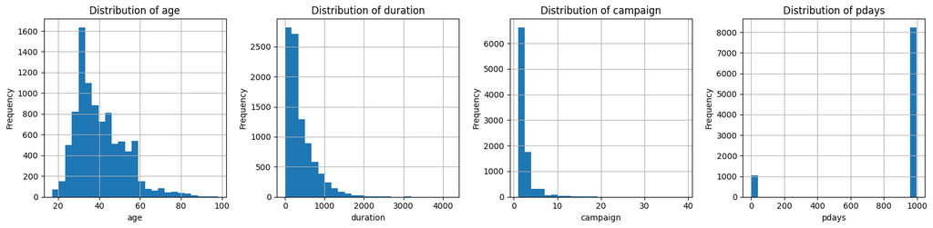

```python
fig, axes = plt.subplots(1, 4, figsize=(16,4))

for ax, var in zip(axes, numeric_vars):
    df[var].hist(bins=25, ax=ax)
    ax.set_title(f"Distribution of {var}", fontsize=12)
    ax.set_xlabel(var)
    ax.set_ylabel("Frequency")

plt.tight_layout()
plt.show()
```

### Task 3B

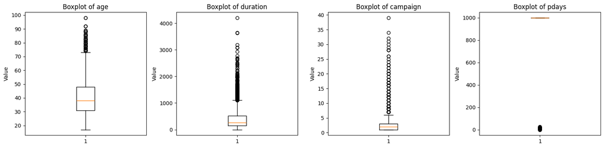

```python
# boxplots
fig, axes = plt.subplots(1, 4, figsize=(16, 4))

for ax, var in zip(axes, numeric_vars):
    ax.boxplot(df[var].dropna())
    ax.set_title(f"Boxplot of {var}", fontsize=12)
    ax.set_xlabel("")
    ax.set_ylabel("Value")

plt.tight_layout()
plt.show()
```

### Task 3C

```python
# deciles
deciles = np.linspace(0, 1, 11)

for var in numeric_vars:
    print(f"\nDeciles for {var}:")
    print(df[var].quantile(deciles))
```

```
Deciles for age:
0.0    17.0
0.1    27.0
0.2    30.0
0.3    33.0
0.4    35.0
0.5    38.0
0.6    41.0
0.7    46.0
0.8    51.0
0.9    57.0
1.0    98.0
Name: age, dtype: float64

Deciles for duration:
0.0       1.0
0.1      80.0
0.2     124.0
0.3     167.0
0.4     211.0
0.5     265.0
0.6     340.0
0.7     452.0
0.8     615.0
0.9     860.0
1.0    4199.0
Name: duration, dtype: float64

Deciles for campaign:
0.0     1.0
0.1     1.0
0.2     1.0
0.3     1.0
0.4     1.0
0.5     2.0
0.6     2.0
0.7     2.0
0.8     3.0
0.9     4.0
1.0    39.0
Name: campaign, dtype: float64

Deciles for pdays:
0.0      0.0
0.1     11.0
0.2    999.0
0.3    999.0
0.4    999.0
0.5    999.0
0.6    999.0
0.7    999.0
0.8    999.0
0.9    999.0
1.0    999.0
Name: pdays, dtype: float64
```

## Task 4

```python
# define categorical variables
categorical_vars = ["y", "day_of_week", "loan", "marital"]
```

### Task 4A

```python
# counts and proportions
for var in categorical_vars:
    counts = df[var].value_counts(dropna=False)
    props = df[var].value_counts(normalize=True, dropna=False).round(4)

    summary = counts.to_frame("count")
    summary["proportion"] = props

    print(f"\nSummary of {var}:")
    print(summary)
```

```
Summary of y:
     count  proportion
y
yes   4640         0.5
no    4640         0.5

Summary of day_of_week:
             count  proportion
day_of_week
thu           2000      0.2155
wed           1861      0.2005
mon           1846      0.1989
tue           1810      0.1950
fri           1763      0.1900

Summary of loan:
         count  proportion
loan
no        7688      0.8284
yes       1367      0.1473
unknown    225      0.0242

Summary of marital:
          count  proportion
marital
married    5338      0.5752
single     2900      0.3125
divorced   1021      0.1100
unknown      21      0.0023
```

### Task 4B

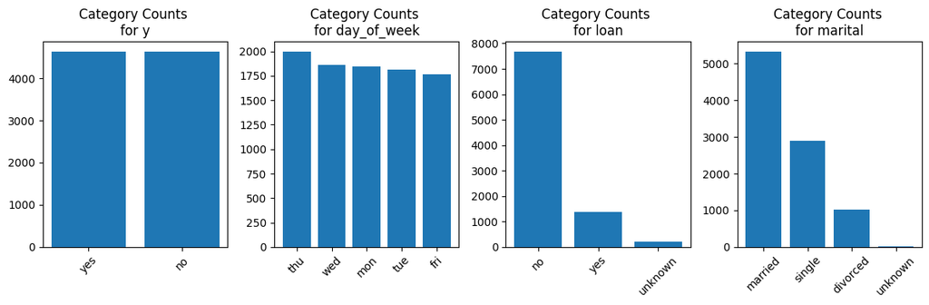

```python
# bar charts
fig, axes = plt.subplots(1, 4, figsize=(12, 4))

for ax, var in zip(axes, categorical_vars):
    counts = df[var].value_counts(dropna=False)
    ax.bar(counts.index.astype(str), counts.values)
    ax.set_title(f"Category Counts \nfor {var}", fontsize=12)
    ax.tick_params(axis="x", rotation=45)

plt.tight_layout()
plt.show()
```

## Task 5

### Task 5A

```python
# correlation matrix
task_5_numeric_vars = ["age", "duration", "campaign", "pdays", "euribor3m", "emp.var.rate", "nr.employed"]

corr = df[task_5_numeric_vars].corr(numeric_only=True)
corr
```

|  | age | duration | campaign | pdays | euribor3m | emp.var.rate | nr.employed |
| --- | --- | --- | --- | --- | --- | --- | --- |
| age | 1.000000 | -0.020727 | 0.003690 | -0.053516 | -0.044627 | -0.049053 | -0.074687 |
| duration | -0.020727 | 1.000000 | -0.025872 | 0.028936 | 0.057340 | 0.071440 | 0.058232 |
| campaign | 0.003690 | -0.025872 | 1.000000 | 0.089301 | 0.175123 | 0.185736 | 0.176972 |
| pdays | -0.053516 | 0.028936 | 0.089301 | 1.000000 | 0.387739 | 0.334888 | 0.474992 |
| euribor3m | -0.044627 | 0.057340 | 0.175123 | 0.387739 | 1.000000 | 0.958402 | 0.940546 |
| emp.var.rate | -0.049053 | 0.071440 | 0.185736 | 0.334888 | 0.958402 | 1.000000 | 0.867530 |
| nr.employed | -0.074687 | 0.058232 | 0.176972 | 0.474992 | 0.940546 | 0.867530 | 1.000000 |

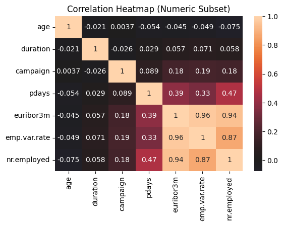

```python
# heatmap
plt.figure(figsize=(6, 4))

sns.heatmap(corr, annot=True, center=0)

plt.title(f"Correlation Heatmap (Numeric Subset)")
plt.show()
```

### Task 5B

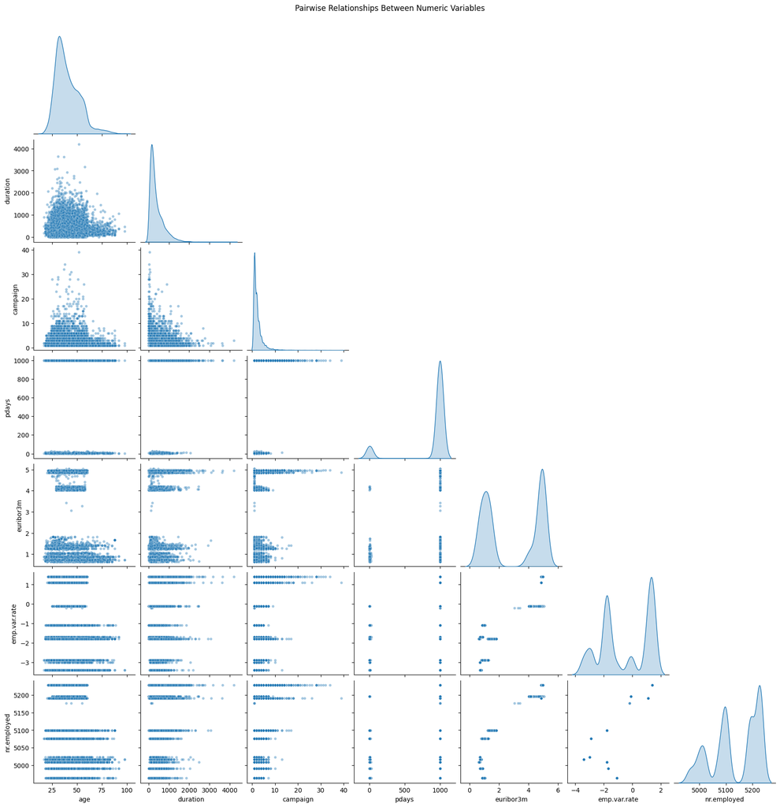

```python
# Pairplot
g = sns.pairplot(
    data=df,
    vars=task_5_numeric_vars,
    diag_kind="kde",
    corner=True,
    plot_kws={"alpha": 0.4, "s": 18}
)

g.fig.suptitle("Pairwise Relationships Between Numeric Variables", y=1.02)
plt.show()
```

### Task 5C

```python
# define numeric variables for task 5c
task_5c_numeric_vars = ["duration", "emp.var.rate", "cons.price.idx", "cons.conf.idx"]
```

#### 5C.i

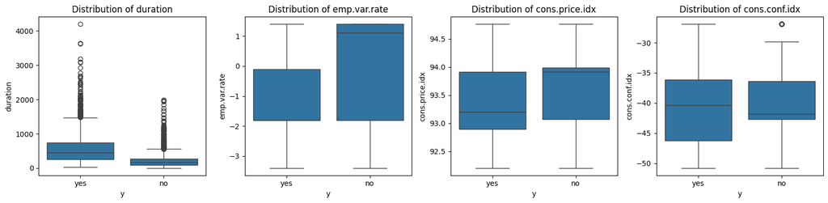

```python
# boxplots
fig, axes = plt.subplots(1, 4, figsize=(16, 4))

for ax, var in zip(axes, task_5c_numeric_vars):
    sns.boxplot(x="y", y=var, data=df, ax=ax)
    ax.set_title(f"{var} by y", fontsize=12)
    ax.set_title(f"Distribution of {var}", fontsize=12)
    ax.set_xlabel("y")
    ax.set_ylabel(var)

plt.tight_layout()
plt.show()
```

#### 5C.ii

```python
# summary statistics
for var in task_5c_numeric_vars:
    print(f"\nStatistics for {var} grouped by y:")
    stats = df.groupby("y")[var].describe()
    print(stats)
```

```
Statistics for duration grouped by y:
      count        mean         std   min    25%    50%     75%     max
y
no   4640.0  221.532328  199.983615   1.0   94.0  166.0  279.25  1994.0
yes  4640.0  553.191164  401.171871  37.0  253.0  449.0  741.25  4199.0

Statistics for emp.var.rate grouped by y:
      count      mean       std  min  25%  50%  75%  max
y
no   4640.0  0.240905  1.484072 -3.4 -1.8  1.1  1.4  1.4
yes  4640.0 -1.233448  1.623626 -3.4 -1.8 -1.8 -0.1  1.4

Statistics for cons.price.idx grouped by y:
      count       mean       std     min     25%     50%     75%     max
y
no   4640.0  93.603969  0.562398  92.201  93.075  93.918  93.994  94.767
yes  4640.0  93.354386  0.676644  92.201  92.893  93.200  93.918  94.767

Statistics for cons.conf.idx grouped by y:
      count       mean       std   min   25%   50%   75%   max
y
no   4640.0 -40.646466  4.406427 -50.8 -42.7 -41.8 -36.4 -26.9
yes  4640.0 -39.789784  6.139668 -50.8 -46.2 -40.4 -36.1 -26.9
```

## Task 6

**Data Description**

The dataset contains 9,280 rows and 21 columns, capturing client demographics, marketing campaign details, economic indicators, and the target variable `y`, which indicates whether a client subscribed to a certified term deposit (CD). The dataset includes both numeric variables (such as `age`, `duration`, and `campaign`) and categorical variables (such as `day_of_week`, `loan`, and `marital status`).

**Numeric Distribution**

The variables `duration` and `campaign` both show right-skewed distributions, with most values concentrated at the lower end and a few extreme values creating long tails. `Age` is also right-skewed, ranging from 17 to 98 with a median of 38, indicating that most clients are middle-aged. `Duration`, the last contact in seconds, has a median of 265 and a maximum of 4,199, showing that most calls last less than 5 minutes, while a few last much longer. `Campaign`, representing the number of contacts during the current campaign, has a median of 2 and a maximum of 39, reflecting that most clients are contacted a few times. Similarly, `pdays`, the number of days since the last contact in a previous campaign, is dominated by the value 999, a placeholder indicating that most clients had not been contacted before.

**Categorical Distribution**

The target variable `y` is evenly split, with half of the clients subscribing to a CD and half not. The distribution of `day_of_week` shows that client contact is highest on Thursdays (21.6%) and lowest on Fridays (19.0%), with Mondays, Tuesdays, and Wednesdays in between. Regarding loan status, most clients (82.8%) do not have a loan, while 14.7% do, and 2.4% are unknown. For marital status, the majority are married (57.5%), followed by single (31.3%) and divorced (11.0%), with a very small fraction (0.2%) unknown.

**Numeric Correlation**

Correlations among numeric variables show that social and economic indicators are highly interrelated. In particular, `euribor3m`, `emp.var.rate`, and `nr.employed` have very strong positive correlations with each other (above 0.85).

**Predictors of Target Variable**

Two variables appear to be strong potential predictors of CD subscription. The average `duration` of the last contact for clients who subscribed was 553 seconds (just over 9 minutes), compared to 222 seconds (just under 4 minutes) for non-subscribers, suggesting that longer calls are associated with positive responses. Similarly, `emp.var.rate`, the employment variation rate, differs substantially between groups: clients who subscribed are associated with lower values (mean = -1.23, median = -1.8) compared to non-subscribers (mean = 0.24, median = 1.1). These differences indicate that both the length of contact and the economic environment captured by employment variation may influence client decisions.